# Example 1.1 Can Dolphins Communicate?

Last updated Monday, September 08, 2025 @ 03:32 PM

## Before We Begin…

These slides were created to accompany the text [*Introduction to Statistical Investigations, 2nd Edition*](http://www.isi-stats.com/isi/index2nd.html) — Section 1.1 Introduction to Chance Models.

*This content does not replace reading the relevant textbook section.* It is for class presentation, review, and reference.

See [AsULearn](https://asulearn.appstate.edu/) for additional readings, videos, and assignments.

You can print these slides to a pdf for offline use using the print function in your browser.

## Learning Goals for Section 1.1

- Recognize the difference between parameters and statistics.
- Describe how to use coin tossing to simulate outcomes from a chance model of a random choice between two events.
- Use the ISI [One Proportion](http://www.isi-stats.com/isi2nd/ISIapplets2021.html) applet to carry out a coin tossing simulation.
- Identify whether or not the results of a study are statistically significant and whether or not a chance model is a plausible explanation for the data.
- Implement the 3S strategy: find a statistic, simulate results from a chance model, and determine strength of evidence.
- Differentiate between saying a chance model is plausible and a chance model is the correct explanation for observed data (i.e., whether or not we have “proven” a result).

## STEP 1: Ask a Research Question

**Research Question:** Can dolphins communicate with each other in an abstract manner?

*The research question influences our study design and hypotheses.*

Why do we care about this?

The research described here was funded by the US Navy as part of its [Marine Mammal Program](https://www.niwcpacific.navy.mil/About/Departments/Intelligence-Surveillance-and-Reconnaissance/Marine-Mammal-Program/). In the early years, beginning in 1959, scientists explored sensory and physical capabilities many different species of marine animals.

Today, the Navy uses bottlenose dolphins (*Tursiops truncatus*) and California sea lions (*Zalophus californianus*) for a variety of jobs, including search, recovery, detection, and security.

## STEP 2: Design a Study and Collect Data

Button-pushing is the **random process** we are observing here.

First, the dolphins had to be trained to push buttons. Dr. Bastian (the researcher) put buttons underwater on each end of a large pool, two for each dolphin—Doris and Buzz.

Bastian used two light signals. (1) Steadily on meant “push the button on the right.” (2) Blinking meant “push the button on the left.” Correct pushes were rewarded with a fish. Doris and Buzz learned to choose the correct button every time.

Next, Dr. Bastian changed the set-up so that Buzz had to push his button before Doris to get a reward. The dolphins adapted and once again learned to perform the task perfectly.

*Why was this pre-training necessary before the “real” experiment?*

Bastian put a curtain across the middle of the pool. Doris could see the light signal, but Buzz could not. When the light came on, Doris swam near the curtain and whistled. Buzz whistled back and pressed the correct button. Bastian repeated this process many times with both the steady light and the blinking light. He observed and recorded Buzz’s button choice on each trial.

**parameter (\(\pi\)):** Buzz’s actual long-run proportion (or *probability*) of pushing the correct button based on whistles from Doris

**observational units:** Buzz’s individual button-pushing attempts (these kinds of attempts are often called *trials*)

**variable of interest:** whether Buzz pushed the correct button or incorrect button on each trial (*binary categorical variable*)

**sample:** the set of observational units on which we collect data

## STEP 3: Explore the Data

In one phase of the study, Dr. Bastian had Buzz attempt to push the correct button a total of \(16\) times. In this sample of \(16\) trials, Buzz pushed the correct button \(15\) out of \(16\) times.

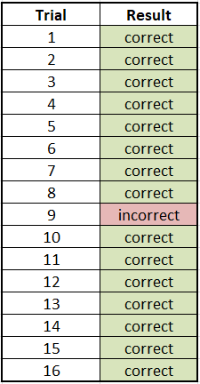

To summarize these results, we report a numerical summary of the sample data that we call a *statistic*.

**Option 1: Count of Successes**

One way we can summarize the data is to report a count of how many times Buzz was correct. The count is \(15\).

**Option 2: Proportion of Successes**

A count can be ambiguous to interpret if we do not consider the context and take the total number of observations into account. For example, \(15/16\) is much different than \(15/100\). Proportion values, however, are always between \(0\) and \(1\).

The proportion is \(15/16 = 0.9375\). We could also say \(93.75\%\). We use the symbol \(\hat{p}\) to represent a sample proportion.

## STEP 4: Draw Inferences

Looking at the data, it certainly seems as if Buzz and Doris can communicate. After all, Buzz pushed the correct button almost every time, even though he couldn’t see the light himself.

The problem is, it is *possible* to get \(15\) out of \(16\) just by guessing.

Therefore, we have two possibilities we have to consider.

- Buzz is just guessing (his probability of a correct button push is \(0.50\)) and just he got lucky in these \(16\) attempts.
- Buzz is doing something other than just guessing (probability of a correct button push is really larger than \(0.50\)).

We have to work with the data we have, so how do we choose?

## The Chance Model

It is fairly straightforward to model what could happen if Buzz is guessing, since the chance of being correct for every trial would be \(0.50\) — he has two buttons with no reason to favor either.

We could use a coin flip as a simple physical / tacile generator.

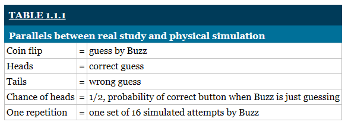

## Running the Simulation

If we flip the coin \(16\) times, we replicate the whole experiment once. Each flip is one *purely random guess* by Buzz.

[figure not shown]

**Simulation 1:** We flipped \(11\) heads (correct guesses) and \(5\) tails, so the simulated statistic is \(11/16 = 0.6875 = 68.75\%\).

[figure not shown]

▶ There is *variability* in our simulation results … so what now?

## The Simulated Distribution

We need to do many, many more simulations do determine the *long-run pattern* in the distribution of the number of heads that we get just from random chance. Remember what you learned about distribution characteristics from Section P.2.

What shape does the distribution have?

What is a center or typical value?

How much variability is there?

What would be unusual? → We will focus on this one right now!

It would be tedious to do a large number of simulations with an actual coin, so we will use the ISI [One Proportion](https://www.isi-stats.com/isi2nd/ISIapplets2021.html) applet.

We will do \(100\) simulations of the experiment, \(16\) trials in each, assuming a purely random chance of correctly choosing (\(0.5\)).

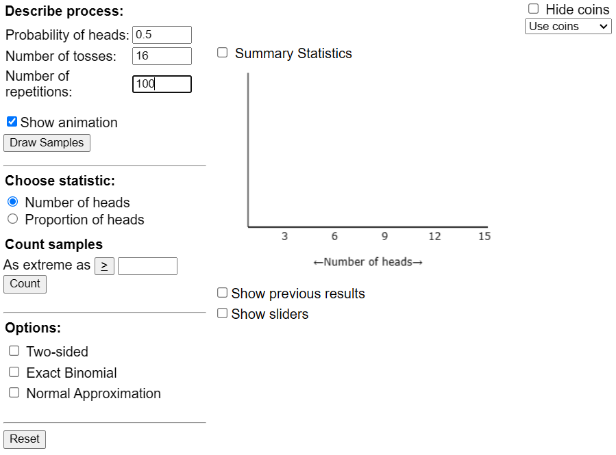

Press `Draw Samples` to generate 100 simulated experiments…

The results of the simulation are displayed using a dotplot or a histogram so we can see the *null distribution* of the statistic.

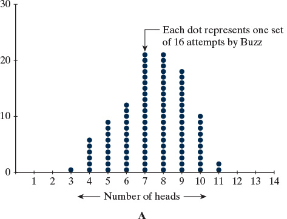

Any number of successes from \(0\) to \(16\) is *possible* if Buzz is just guessing. This dotplot of our simulation results shows us which of these possible values are more *probable* or *likely* to happen.

When we talk about a long-term probability, \(100\) simulations is not really very long-term. The textbook suggests at least 1000.

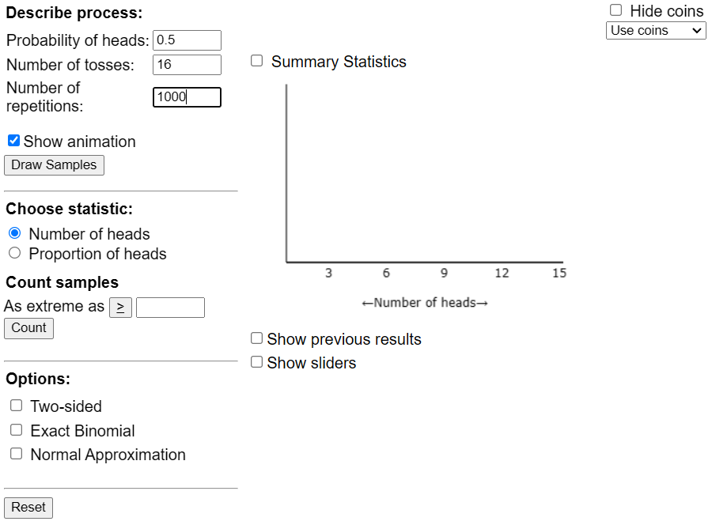

Press `Draw Samples` to generate 1000 simulated experiments…

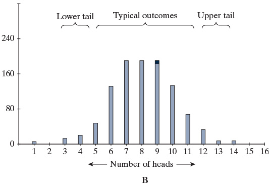

Doing a larger number of simulations gives us a better idea of the long-run probability for all the possible outcomes. Getting between \(5\) and \(11\) just by guessing is not all that unusual.

## If We Did Infinite Simulations…

The plot shows the true long-run probabilities of getting \(0\) to \(16\) correct, if Buzz is guessing on each trial. Getting \(8\) of \(16\) (\(50\%\)) is the most common outcome, as we would predict, with numbers of successes becoming less likely as we go lower or higher.

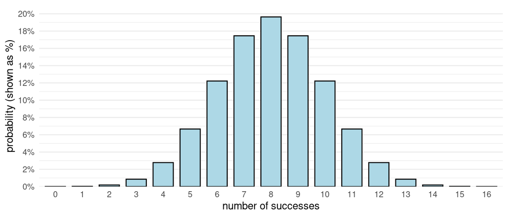

## Let’s Zoom In a Little

If we zoom in on the distribution’s upper tail, we can get an idea of how *very* unusual it is to get \(15\) trials correct by just randomly guessing. As we said earlier, it is *possible*, but not *probable*.

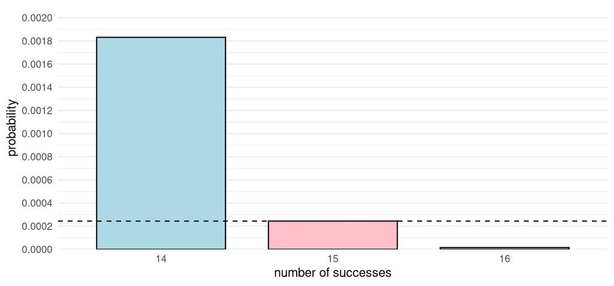

## Simulations Get Us Close Enough!

Most traditional statistical methods are *approximations* that use probability theory and mathematics. Section 1.5 (which we will not cover) presents a method that approximates probabilities using the Normal distribution (“bell curve”). You may have seen this method in AP Statistics or a research methods class.

Historically, we used these methods because of the challenges of calculating the values we needed without technology.

In this course, we will use simulations to approximate long-run probabilities. In many ways, simulations can be preferable and more flexible than theory-based methods.

In any case, we can see that getting \(15\) out of \(16\) correct just by randomly guessing is a *very* unlikely, but not impossible.

## When is the Probability Small Enough?

We saw that the probability of Buzz getting \(15\) of \(16\) correct just by randomly guessing is very, very small—somewhere between \(0.0002\) and \(0.0003\). At that level, it is probably safe to say that most people would agree with the conclusion that Buzz was not just guessing.

But what if the probability had not been quite so low? What if it was \(1\%\)? Or \(4\%\)? Or \(12\%\)?

Overall, we need a quantifiable and consistent way to make our statistical decisions. In upcoming sections, you will learn about *p*-values and *z*-scores, two methods for assessing the plausibility of “just randomness” as an explanation for the observed results of a research study.

## STEP 5: Formulate Conclusions

**Definition:** A result is deemed to be *statistically significant* if it is unlikely to occur solely by random chance. In other words, the chance model is an *implausible* explanation for the results that were observed in the study being evaluated.

Notice that the conclusions we make are based on probability. We *cannot* declare that we have proof either way.

Here, the number of correct buttons Buzz pushed is outside the typical variability we would expect if he were just guessing. That means we have *strong evidence* that he is not just guessing. It is therefore logical to decide that he is *not* guessing.

If our observed result appears to be consistent with the chance model, we say the chance model is *plausible* or *believable*.

**So … what additional questions might this conclusion raise?**

- If Buzz is not guessing, then what is he actually doing?
- If Buzz and Doris can communicate, can other dolphins?

Some conclusions will depend on how the study was designed and how we view this set of 16 observed attempts relative to the bigger picture of the research question.

For example, we have assumed some things about this study.

- Buzz couldn’t see the light himself.
- The type of light signal was chosen randomly so Buzz couldn’t figure out a pattern to help him decide which button to push.
- Buzz’s 16 attempts here represent what Buzz would do given many more attempts under identical conditions.

## STEP 6: Look Back and Ahead

After Steps 1–5 of our six-step statistical investigation method, we need to revisit the big picture of our research question.

We need to reflect on the limitations of this study and analysis, and consider future studies. Overall, we are stepping back and thinking about the big research question more than the specific research conjecture that was being tested in this study.

In some ways, this is the most important step in the process—it is where we consider the true implications of the scientific study we conducted and where it fits in the body of knowledge.

For this study, we would critique on Dr. Bastian’s methodology, summarize the results for Buzz, and reflect on ways to improve the study to confirm and enhance our conclusions.

## References

Bastian, J., Wall, C., and Anderson, C. L. (1966). The transmission of arbitrary environmental information between bottlenosed dolphins. In R.G. Busnel (Ed.), *Animal Sonar Systems–Biology and Bionics*, Vol. II (pp. 803–873). France: Laboratoire de Physiologie Acoustique.

Naval Info Warfare Center Pacific. *Marine Mammal Program*. https://www.niwcpacific.navy.mil/About/Departments/Intelligence-Surveillance-and-Reconnaissance/Marine-Mammal-Program/